# F3 changes in Glasgow vowels / r

# Data wrangling

Let’s import the data and relevant libraries first.

```r
library(lme4)
library(mgcv)
library(itsadug)
library(rms)
library(tidyverse)
library(stringr)
library(effects)
library(here)
library(afex)
refit_please <- F # please don't refit all the models - just load them from RDS files
vowels <- read_csv("data/vowels.csv")
```

# Data visualisation

Here is a summary of the data.

```r
summary(vowels)
```

```
   Speaker             gender          Target.stress      Target.CELEX.phonemes Target.orthography
 Length:7556        Length:7556        Length:7556        Length:7556           Length:7556
 Class :character   Class :character   Class :character   Class :character      Class :character
 Mode  :character   Mode  :character   Mode  :character   Mode  :character      Mode  :character



 Match.segments     Target.segments    Target.segments.start Target.segments.end    time_0.5
 Length:7556        Length:7556        Min.   :   3.916      Min.   :   4.066    Min.   :   3.991
 Class :character   Class :character   1st Qu.: 603.624      1st Qu.: 603.681    1st Qu.: 603.653
 Mode  :character   Mode  :character   Median :1182.570      Median :1182.634    Median :1182.602
                                       Mean   :1204.725      Mean   :1204.841    Mean   :1204.783
                                       3rd Qu.:1794.272      3rd Qu.:1794.419    3rd Qu.:1794.346
                                       Max.   :3003.172      Max.   :3003.302    Max.   :3003.237
    vowel            preceding          following            decade          decade.fact
 Length:7556        Length:7556        Length:7556        Length:7556        Length:7556
 Class :character   Class :character   Class :character   Class :character   Class :character
 Mode  :character   Mode  :character   Mode  :character   Mode  :character   Mode  :character



    duration            f1               f2             f3
 Min.   :0.0300   Min.   : 313.0   Min.   : 803   Min.   :1607
 1st Qu.:0.0700   1st Qu.: 418.0   1st Qu.:1220   1st Qu.:2325
 Median :0.1100   Median : 503.0   Median :1468   Median :2543
 Mean   :0.1158   Mean   : 524.9   Mean   :1528   Mean   :2548
 3rd Qu.:0.1500   3rd Qu.: 604.0   3rd Qu.:1777   3rd Qu.:2759
 Max.   :0.9200   Max.   :1026.0   Max.   :2882   Max.   :3664
```

Let’s go through the list:

- Speaker as random intercept
- gender as fixed pred, possibly in interaction with decade
- for simplicity, decade as linear?
- vowel duration with random slopes by vowel
- random intercepts by vowel, following, preceding

Would be nice to create some raw plots. How about boxplots of F2 / F3 / vowel / gender?

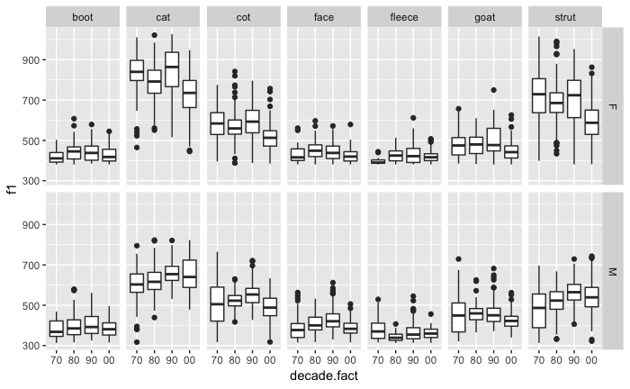

```r
vowels$decade.fact <- factor(vowels$decade.fact, levels=c("70","80","90","00"))
ggplot(vowels, aes(x=decade.fact, y=f1)) +
  facet_grid(gender ~ vowel) +
  geom_boxplot()
```

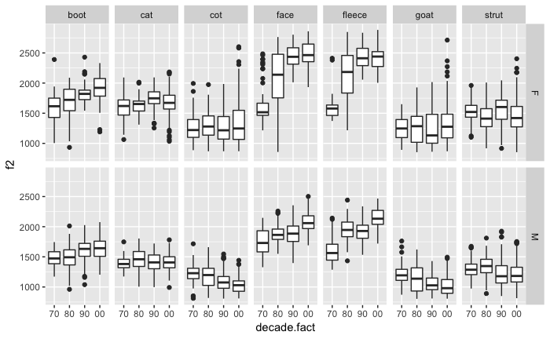

```r
ggplot(vowels, aes(x=decade.fact, y=f2)) +
  facet_grid(gender ~ vowel) +
  geom_boxplot()
```

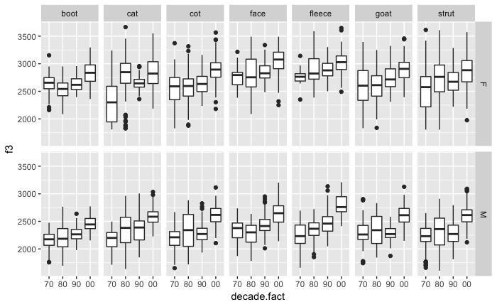

```r
ggplot(vowels, aes(x=decade.fact, y=f3)) +
  facet_grid(gender ~ vowel) +
  geom_boxplot()
```

This is *awesome*! F1/F2 shows all kinds of changes / stable distributions, perhaps unsurprisingly. However, F3 rises very consistently across all vowels for both genders.

# Modelling F1/F2/F3

We’ll test this using linear mixed models. The dependent variables will be F1/F2/F3. We’ll run the models one by one.

Data formatting:

```r
vowels$Speaker <- as.factor(vowels$Speaker)
vowels$Target.orthography <- as.factor(vowels$Target.orthography)
vowels$vowel <- as.factor(vowels$vowel)
vowels$decade <- ifelse(vowels$decade=="00", 2000, as.numeric(vowels$decade) + 1900)
vowels$decade.fact <- factor(vowels$decade.fact, levels=c("70","80","90","00"))
```

First F1:

```r
# this is the model that we would like to have - but it
# does not converge due to a singularity involving
# the decade by vowel random slope
# f1.mod.full <- lmer(f1 ~ gender * decade.fact +
#                           scale(duration) +
#                             (1 + decade.fact | vowel) +
#                             (1 | Target.orthography) +
#                             (1 | Speaker),
#               data=vowels, REML=F)
# these are two alternative models; model 1 forces the decade
# effect to be linear
if (refit_please) {
  f1.mod.full.1 <- lmer(f1 ~ gender * scale(decade) +
                           scale(duration) +
                               (1 + scale(decade) | vowel) +
                               (1 | Target.orthography) +
                               (1 | Speaker),
                 data=vowels, REML=F)
  # saveRDS(f1.mod.full.1, "models/f1.mod.full.1")

  # model 2 has no by-vowel random slope for decade (but the decade
  # effect is allowed to be non-linear)

  f1.mod.full.2 <- lmer(f1 ~ gender * decade.fact +
                           scale(duration) +
                               (1 | vowel) +
                               (1 | Target.orthography) +
                               (1 | Speaker),
                 data=vowels, REML=F)
  # saveRDS(f1.mod.full.2, "models/f1.mod.full.2")
  #summary(f3.mod.full)

  # neither model shows a significant effect of decade:
  # (and note that model 2 is expected to be anti-conservative with
  #  respect to decade!)

  f1.mod.comp.1 <- lmer(f1 ~ gender + scale(duration) +
                               (1 + scale(decade) | vowel) +
                               (1 | Target.orthography) +
                               (1 | Speaker),
                 data=vowels, REML=F)
  # saveRDS(f1.mod.comp.1, "models/f1.mod.comp.1")
  f1.mod.comp.2 <- lmer(f1 ~ gender + scale(duration) +
                               (1 | vowel) +
                               (1 | Target.orthography) +
                               (1 | Speaker),
                 data=vowels, REML=F)
  # saveRDS(f1.mod.comp.2, "models/f1.mod.comp.2")
}
f1.mod.full.1 <- readRDS("models/f1.mod.full.1")
f1.mod.full.2 <- readRDS("models/f1.mod.full.2")
f1.mod.comp.1 <- readRDS("models/f1.mod.comp.1")
f1.mod.comp.2 <- readRDS("models/f1.mod.comp.2")
anova(f1.mod.full.1, f1.mod.comp.1)
```

```
Data: vowels
Models:
f1.mod.comp.1: f1 ~ gender + scale(duration) + (1 + scale(decade) | vowel) +
f1.mod.comp.1:     (1 | Target.orthography) + (1 | Speaker)
f1.mod.full.1: f1 ~ gender * scale(decade) + scale(duration) + (1 + scale(decade) |
f1.mod.full.1:     vowel) + (1 | Target.orthography) + (1 | Speaker)
              Df   AIC   BIC logLik deviance Chisq Chi Df Pr(>Chisq)
f1.mod.comp.1  9 85694 85756 -42838    85676
f1.mod.full.1 11 85695 85772 -42837    85673 2.381      2     0.3041
```

```r
anova(f1.mod.full.2, f1.mod.comp.2)
```

```
Data: vowels
Models:
f1.mod.comp.2: f1 ~ gender + scale(duration) + (1 | vowel) + (1 | Target.orthography) +
f1.mod.comp.2:     (1 | Speaker)
f1.mod.full.2: f1 ~ gender * decade.fact + scale(duration) + (1 | vowel) + (1 |
f1.mod.full.2:     Target.orthography) + (1 | Speaker)
              Df   AIC   BIC logLik deviance  Chisq Chi Df Pr(>Chisq)
f1.mod.comp.2  7 85710 85759 -42848    85696
f1.mod.full.2 13 85717 85807 -42845    85691 5.4121      6     0.4921
```

```r
# this is the model that we would like to have - but it
# does not converge due to a singularity involving
# the decade by vowel random slope
# f2.mod.full <- lmer(f2 ~ gender * decade.fact +
#                           scale(duration) +
#                             (1 + decade.fact | vowel) +
#                             (1 | Target.orthography) +
#                             (1 | Speaker),
#               data=vowels, REML=F)
# these are two alternative models; model 1 forces the decade
# effect to be linear
if (refit_please) {
  f2.mod.full.1 <- lmer(f2 ~ gender * scale(decade) +
                           scale(duration) +
                               (1 + scale(decade) | vowel) +
                               (1 | Target.orthography) +
                               (1 | Speaker),
                 data=vowels, REML=F)
  # saveRDS(f2.mod.full.1, "models/f2.mod.full.1")

  # model 2 has no by-vowel random slope for decade (but the decade
  # effect is allowed to be non-linear)

  f2.mod.full.2 <- lmer(f2 ~ gender * decade.fact +
                           scale(duration) +
                               (1 | vowel) +
                               (1 | Target.orthography) +
                               (1 | Speaker),
                 data=vowels, REML=F)
  # saveRDS(f2.mod.full.2, "models/f2.mod.full.2")
  #summary(f3.mod.full)

  # neither model shows a significant effect of decade:
  # (and note that model 2 is expected to be anti-conservative with
  #  respect to decade!)

  f2.mod.comp.1 <- lmer(f2 ~ gender + scale(duration) +
                               (1 + scale(decade) | vowel) +
                               (1 | Target.orthography) +
                               (1 | Speaker),
                 data=vowels, REML=F)
  # saveRDS(f2.mod.comp.1, "models/f2.mod.comp.1")
  f2.mod.comp.2 <- lmer(f2 ~ gender + scale(duration) +
                               (1 | vowel) +
                               (1 | Target.orthography) +
                               (1 | Speaker),
                 data=vowels, REML=F)
  # saveRDS(f2.mod.comp.2, "models/f2.mod.comp.2")
}
f2.mod.full.1 <- readRDS("models/f2.mod.full.1")
f2.mod.comp.1 <- readRDS("models/f2.mod.comp.1")
f2.mod.full.2 <- readRDS("models/f2.mod.full.2")
f2.mod.comp.2 <- readRDS("models/f2.mod.comp.2")
anova(f2.mod.full.1, f2.mod.comp.1)
```

```
Data: vowels
Models:
f2.mod.comp.1: f2 ~ gender + scale(duration) + (1 + scale(decade) | vowel) +
f2.mod.comp.1:     (1 | Target.orthography) + (1 | Speaker)
f2.mod.full.1: f2 ~ gender * scale(decade) + scale(duration) + (1 + scale(decade) |
f2.mod.full.1:     vowel) + (1 | Target.orthography) + (1 | Speaker)
              Df    AIC    BIC logLik deviance  Chisq Chi Df Pr(>Chisq)
f2.mod.comp.1  9 101665 101727 -50823   101647
f2.mod.full.1 11 101664 101740 -50821   101642 5.0774      2    0.07897 .
---
Signif. codes:  0 ‘***’ 0.001 ‘**’ 0.01 ‘*’ 0.05 ‘.’ 0.1 ‘ ’ 1
```

```r
anova(f2.mod.full.2, f2.mod.comp.2)
```

```
Data: vowels
Models:
f2.mod.comp.2: f2 ~ gender + scale(duration) + (1 | vowel) + (1 | Target.orthography) +
f2.mod.comp.2:     (1 | Speaker)
f2.mod.full.2: f2 ~ gender * decade.fact + scale(duration) + (1 | vowel) + (1 |
f2.mod.full.2:     Target.orthography) + (1 | Speaker)
              Df    AIC    BIC logLik deviance  Chisq Chi Df Pr(>Chisq)
f2.mod.comp.2  7 102735 102783 -51360   102721
f2.mod.full.2 13 102742 102833 -51358   102716 4.4788      6     0.6122
```

F2 does not show a significant change.

Now for F3:

```r
anova(f3.mod.full, f3.mod.comp)
```

```
Data: vowels
Models:
f3.mod.comp: f3 ~ gender + scale(duration) + (1 + decade.fact | vowel) + (1 |
f3.mod.comp:     Target.orthography) + (1 | Speaker)
f3.mod.full: f3 ~ gender * decade.fact + scale(duration) + (1 + decade.fact |
f3.mod.full:     vowel) + (1 | Target.orthography) + (1 | Speaker)
            Df    AIC    BIC logLik deviance  Chisq Chi Df Pr(>Chisq)
f3.mod.comp 16 102962 103073 -51465   102930
f3.mod.full 22 102952 103105 -51454   102908 22.166      6    0.00113 **
---
Signif. codes:  0 ‘***’ 0.001 ‘**’ 0.01 ‘*’ 0.05 ‘.’ 0.1 ‘ ’ 1
```

This is so cool! F3 clearly rises very significantly over time. Here’s a plot:

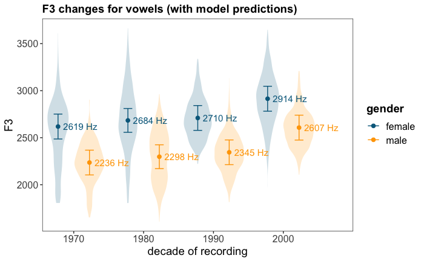

## Acoustic analysis of /r/

Data import / wrangling:

```r
# and again!
R <- read_csv("data/R.csv", col_types=coltyps)
```

[output not shown]

# Males without baseline control

Analysing males first, no baseline F3. Fitting:

- model without AR for estimating rho
- full model with AR
- nested model with AR (rho from full model)

```r
if (refit_please) {
  system.time(
    R.m.mod.no.AR <- bam(f3 ~ stress +
                       # level 1 smooth terms
                          s(measurement.no) +
                          s(decade, k=4) +
                          s(duration) +
                          s(preceding.front, k=3) +
                       # level 2: by terms
                          s(measurement.no, by=stress) +
                          s(decade, k=4, by=stress) +
                       # level 2: 2d smooths
                          ti(measurement.no, decade, k=c(10,4)) +
                          ti(measurement.no, duration) +
                          ti(measurement.no, preceding.front, k=c(10,3)) +
                       # level 3: 2d smooth by terms
                          ti(measurement.no, decade, k=c(10,4), by=stress) +
                       # random smooths
                          s(measurement.no, foll.broad.f3, bs="fs", m=1, k=4) +
                          s(measurement.no, speaker, bs="fs", m=1, k=4) +
                          s(measurement.no, word, bs="fs", m=1, k=4),
                      dat=R.m)
  )
  # saveRDS(R.m.mod.no.AR, "models/R.m.mod.no.AR")

  R.m.rho <- start_value_rho(R.m.mod.no.AR)

  system.time(
    R.m.mod.AR <- bam(f3 ~ stress +
                       # level 1 smooth terms
                          s(measurement.no) +
                          s(decade, k=4) +
                          s(duration) +
                          s(preceding.front, k=3) +
                       # level 2: by terms
                          s(measurement.no, by=stress) +
                          s(decade, k=4, by=stress) +
                       # level 2: 2d smooths
                          ti(measurement.no, decade, k=c(10,4)) +
                          ti(measurement.no, duration) +
                          ti(measurement.no, preceding.front, k=c(10,3)) +
                       # level 3: 2d smooth by terms
                          ti(measurement.no, decade, k=c(10,4), by=stress) +
                       # random smooths
                          s(measurement.no, foll.broad.f3, bs="fs", m=1, k=4) +
                          s(measurement.no, speaker, bs="fs", m=1, k=4) +
                          s(measurement.no, word, bs="fs", m=1, k=4),
                      dat=R.m, method="ML",
                      AR.start=R.m$start.event, rho=R.m.rho)
  )
  # saveRDS(R.m.mod.AR, "models/R.m.mod.AR")

  summary(R.m.mod.AR)

  system.time(
    R.m.mod.AR.min.decade <- bam(f3 ~ stress +
                       # level 1 smooth terms
                          s(measurement.no) +
                          #s(decade, k=4) +
                          s(duration) +
                          s(preceding.front, k=3) +
                       # level 2: by terms
                          s(measurement.no, by=stress) +
                          #s(decade, k=4, by=stress) +
                       # level 2: 2d smooths
                          #ti(measurement.no, decade, k=c(10,4)) +
                          ti(measurement.no, duration) +
                          ti(measurement.no, preceding.front, k=c(10,3)) +
                       # level 3: 2d smooth by terms
                          #ti(measurement.no, decade, k=c(10,4), by=stress) +
                       # random smooths
                          s(measurement.no, foll.broad.f3, bs="fs", m=1, k=4) +
                          s(measurement.no, speaker, bs="fs", m=1, k=4) +
                          s(measurement.no, word, bs="fs", m=1, k=4),
                      dat=R.m, method="ML",
                      AR.start=R.m$start.event, rho=R.m.rho)
  )
# saveRDS(R.m.mod.AR.min.decade, "models/R.m.mod.AR.min.decade")
}
R.m.mod.no.AR <- readRDS("models/R.m.mod.no.AR")
R.m.mod.AR <- readRDS("models/R.m.mod.AR")
R.m.mod.AR.min.decade <- readRDS("models/R.m.mod.AR.min.decade")
compareML(R.m.mod.AR, R.m.mod.AR.min.decade)
```

```
R.m.mod.AR: f3 ~ stress + s(measurement.no) + s(decade, k = 4) + s(duration) +
    s(preceding.front, k = 3) + s(measurement.no, by = stress) +
    s(decade, k = 4, by = stress) + ti(measurement.no, decade,
    k = c(10, 4)) + ti(measurement.no, duration) + ti(measurement.no,
    preceding.front, k = c(10, 3)) + ti(measurement.no, decade,
    k = c(10, 4), by = stress) + s(measurement.no, foll.broad.f3,
    bs = "fs", m = 1, k = 4) + s(measurement.no, speaker, bs = "fs",
    m = 1, k = 4) + s(measurement.no, word, bs = "fs", m = 1,
    k = 4)

R.m.mod.AR.min.decade: f3 ~ stress + s(measurement.no) + s(duration) + s(preceding.front,
    k = 3) + s(measurement.no, by = stress) + ti(measurement.no,
    duration) + ti(measurement.no, preceding.front, k = c(10,
    3)) + s(measurement.no, foll.broad.f3, bs = "fs", m = 1,
    k = 4) + s(measurement.no, speaker, bs = "fs", m = 1, k = 4) +
    s(measurement.no, word, bs = "fs", m = 1, k = 4)

Chi-square test of ML scores
-----
```

| Model | Score | Edf | Difference | Df | p.value | Sig. |
| --- | --- | --- | --- | --- | --- | --- |
| R.m.mod.AR.min.decade | 25015.80 | 22 |  |  |  |  |
| R.m.mod.AR | 25006.28 | 32 | 9.519 | 10.000 | 0.040 | * |

```
AIC difference: -0.11, model R.m.mod.AR has lower AIC.
```

```
 AIC might not be reliable, as an AR1 model is included (rho1 = 0.848517, rho2 = 0.848517).
```

```
Predictor decade is not a factor.
```

```
Summary:
    * stress : factor; set to the value(s): full.
    * measurement.no : numeric predictor; with 30 values ranging from 0.000000 to 10.000000.
    * decade : numeric predictor; with 4 values ranging from 1970.000000 to 2000.000000.
    * duration : numeric predictor; set to the value(s): 0.122709575.
    * preceding.front : numeric predictor; set to the value(s): 1.
    * foll.broad.f3 : factor; set to the value(s): labial. (Might be canceled as random effect, check below.)
    * speaker : factor; set to the value(s): 00-O-m06. (Might be canceled as random effect, check below.)
    * word : factor; set to the value(s): were. (Might be canceled as random effect, check below.)
    * NOTE : The following random effects columns are canceled: s(measurement.no,foll.broad.f3),s(measurement.no,speaker),s(measurement.no,word)
```

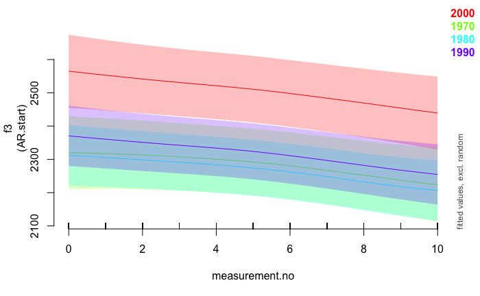

```r
plot_smooth(R.m.mod.AR, view="measurement.no", plot_all="decade",
            cond=list(stress="full"), rm.ranef=T)
```

```
Predictor decade is not a factor.
```

```
Summary:
    * stress : factor; set to the value(s): schwa.
    * measurement.no : numeric predictor; with 30 values ranging from 0.000000 to 10.000000.
    * decade : numeric predictor; with 4 values ranging from 1970.000000 to 2000.000000.
    * duration : numeric predictor; set to the value(s): 0.122709575.
    * preceding.front : numeric predictor; set to the value(s): 1.
    * foll.broad.f3 : factor; set to the value(s): labial. (Might be canceled as random effect, check below.)
    * speaker : factor; set to the value(s): 00-O-m06. (Might be canceled as random effect, check below.)
    * word : factor; set to the value(s): were. (Might be canceled as random effect, check below.)
    * NOTE : The following random effects columns are canceled: s(measurement.no,foll.broad.f3),s(measurement.no,speaker),s(measurement.no,word)
```

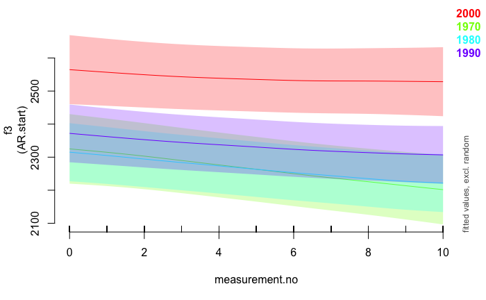

```r
plot_smooth(R.m.mod.AR, view="measurement.no", plot_all="decade",
            cond=list(stress="schwa"), rm.ranef=T)
```

Further questions:

- overall effect of stress?
- significant change in shape?
- do unstressed / stressed syllables show different changes?
- different shape change?
- different overall change?

```r
if (refit_please) {
  # overall stress?
  system.time(
    R.m.mod.AR.min.stress <- bam(f3 ~ #stress +
                       # level 1 smooth terms
                          s(measurement.no) +
                          s(decade, k=4) +
                          s(duration) +
                          s(preceding.front, k=3) +
                       # level 2: by terms
                          #s(measurement.no, by=stress) +
                          #s(decade, k=4, by=stress) +
                       # level 2: 2d smooths
                          ti(measurement.no, decade, k=c(10,4)) +
                          ti(measurement.no, duration) +
                          ti(measurement.no, preceding.front, k=c(10,3)) +
                       # level 3: 2d smooth by terms
                          #ti(measurement.no, decade, k=c(10,4), by=stress) +
                       # random smooths
                          s(measurement.no, foll.broad.f3, bs="fs", m=1, k=4) +
                          s(measurement.no, speaker, bs="fs", m=1, k=4) +
                          s(measurement.no, word, bs="fs", m=1, k=4),
                      dat=R.m, method="ML",
                      AR.start=R.m$start.event, rho=R.m.rho)
  )
  # saveRDS(R.m.mod.AR.min.stress, "models/R.m.mod.AR.min.stress")
  # shape change?
  system.time(
    R.m.mod.AR.min.decade.shape <- bam(f3 ~ stress +
                       # level 1 smooth terms
                          s(measurement.no) +
                          s(decade, k=4) +
                          s(duration) +
                          s(preceding.front, k=3) +
                       # level 2: by terms
                          s(measurement.no, by=stress) +
                          s(decade, k=4, by=stress) +
                       # level 2: 2d smooths
                          #ti(measurement.no, decade, k=c(10,4)) +
                          ti(measurement.no, duration) +
                          ti(measurement.no, preceding.front, k=c(10,3)) +
                       # level 3: 2d smooth by terms
                          #ti(measurement.no, decade, k=c(10,4), by=stress) +
                       # random smooths
                          s(measurement.no, foll.broad.f3, bs="fs", m=1, k=4) +
                          s(measurement.no, speaker, bs="fs", m=1, k=4) +
                          s(measurement.no, word, bs="fs", m=1, k=4),
                      dat=R.m, method="ML",
                      AR.start=R.m$start.event, rho=R.m.rho)
  )
  # saveRDS(R.m.mod.AR.min.decade.shape, "models/R.m.mod.AR.min.decade.shape")
  # overall stress x decade?
  system.time(
    R.m.mod.AR.min.decade.stress <- bam(f3 ~ stress +
                       # level 1 smooth terms
                          s(measurement.no) +
                          s(decade, k=4) +
                          s(duration) +
                          s(preceding.front, k=3) +
                       # level 2: by terms
                          s(measurement.no, by=stress) +
                          #s(decade, k=4, by=stress) +
                       # level 2: 2d smooths
                          ti(measurement.no, decade, k=c(10,4)) +
                          ti(measurement.no, duration) +
                          ti(measurement.no, preceding.front, k=c(10,3)) +
                       # level 3: 2d smooth by terms
                          #ti(measurement.no, decade, k=c(10,4), by=stress) +
                       # random smooths
                          s(measurement.no, foll.broad.f3, bs="fs", m=1, k=4) +
                          s(measurement.no, speaker, bs="fs", m=1, k=4) +
                          s(measurement.no, word, bs="fs", m=1, k=4),
                      dat=R.m, method="ML",
                      AR.start=R.m$start.event, rho=R.m.rho)
  )
  # saveRDS(R.m.mod.AR.min.decade.stress, "models/R.m.mod.AR.min.decade.stress")

  # shape stress x decade?

  system.time(
    R.m.mod.AR.min.decade.stress.shape <- bam(f3 ~ stress +
                       # level 1 smooth terms
                          s(measurement.no) +
                          s(decade, k=4) +
                          s(duration) +
                          s(preceding.front, k=3) +
                       # level 2: by terms
                          s(measurement.no, by=stress) +
                          s(decade, k=4, by=stress) +
                       # level 2: 2d smooths
                          ti(measurement.no, decade, k=c(10,4)) +
                          ti(measurement.no, duration) +
                          ti(measurement.no, preceding.front, k=c(10,3)) +
                       # level 3: 2d smooth by terms
                          #ti(measurement.no, decade, k=c(10,4), by=stress) +
                       # random smooths
                          s(measurement.no, foll.broad.f3, bs="fs", m=1, k=4) +
                          s(measurement.no, speaker, bs="fs", m=1, k=4) +
                          s(measurement.no, word, bs="fs", m=1, k=4),
                      dat=R.m, method="ML",
                      AR.start=R.m$start.event, rho=R.m.rho)
  )
  # saveRDS(R.m.mod.AR.min.decade.stress.shape, "models/R.m.mod.AR.min.decade.stress.shape")
}

R.m.mod.AR.min.stress <- readRDS("models/R.m.mod.AR.min.stress")
R.m.mod.AR.min.decade.shape <- readRDS("models/R.m.mod.AR.min.decade.shape")
R.m.mod.AR.min.decade.stress <- readRDS("models/R.m.mod.AR.min.decade.stress")
R.m.mod.AR.min.decade.stress.shape <- readRDS("models/R.m.mod.AR.min.decade.stress.shape")
# overall stress?
compareML(R.m.mod.AR, R.m.mod.AR.min.stress, suggest.report=T) # non-sig
```

```
R.m.mod.AR: f3 ~ stress + s(measurement.no) + s(decade, k = 4) + s(duration) +
    s(preceding.front, k = 3) + s(measurement.no, by = stress) +
    s(decade, k = 4, by = stress) + ti(measurement.no, decade,
    k = c(10, 4)) + ti(measurement.no, duration) + ti(measurement.no,
    preceding.front, k = c(10, 3)) + ti(measurement.no, decade,
    k = c(10, 4), by = stress) + s(measurement.no, foll.broad.f3,
    bs = "fs", m = 1, k = 4) + s(measurement.no, speaker, bs = "fs",
    m = 1, k = 4) + s(measurement.no, word, bs = "fs", m = 1,
    k = 4)

R.m.mod.AR.min.stress: f3 ~ s(measurement.no) + s(decade, k = 4) + s(duration) + s(preceding.front,
    k = 3) + ti(measurement.no, decade, k = c(10, 4)) + ti(measurement.no,
    duration) + ti(measurement.no, preceding.front, k = c(10,
    3)) + s(measurement.no, foll.broad.f3, bs = "fs", m = 1,
    k = 4) + s(measurement.no, speaker, bs = "fs", m = 1, k = 4) +
    s(measurement.no, word, bs = "fs", m = 1, k = 4)

Report suggestion: The Chi-Square test on the ML scores indicates that model R.m.mod.AR is [not significantly?] better than model R.m.mod.AR.min.stress (X2(8.00)=6.385, p>.1).
-----
```

| Model | Score | Edf | Difference | Df | p.value | Sig. |
| --- | --- | --- | --- | --- | --- | --- |
| R.m.mod.AR.min.stress | 25012.67 | 24 |  |  |  |  |
| R.m.mod.AR | 25006.28 | 32 | 6.385 | 8.000 | 0.120 |  |

```
AIC difference: -8.00, model R.m.mod.AR has lower AIC.
```

```
 AIC might not be reliable, as an AR1 model is included (rho1 = 0.848517, rho2 = 0.848517).
```

```r
# shape change?
compareML(R.m.mod.AR, R.m.mod.AR.min.decade.shape, suggest.report=T) # non-sig
```

```
R.m.mod.AR: f3 ~ stress + s(measurement.no) + s(decade, k = 4) + s(duration) +
    s(preceding.front, k = 3) + s(measurement.no, by = stress) +
    s(decade, k = 4, by = stress) + ti(measurement.no, decade,
    k = c(10, 4)) + ti(measurement.no, duration) + ti(measurement.no,
    preceding.front, k = c(10, 3)) + ti(measurement.no, decade,
    k = c(10, 4), by = stress) + s(measurement.no, foll.broad.f3,
    bs = "fs", m = 1, k = 4) + s(measurement.no, speaker, bs = "fs",
    m = 1, k = 4) + s(measurement.no, word, bs = "fs", m = 1,
    k = 4)

R.m.mod.AR.min.decade.shape: f3 ~ stress + s(measurement.no) + s(decade, k = 4) + s(duration) +
    s(preceding.front, k = 3) + s(measurement.no, by = stress) +
    s(decade, k = 4, by = stress) + ti(measurement.no, duration) +
    ti(measurement.no, preceding.front, k = c(10, 3)) + s(measurement.no,
    foll.broad.f3, bs = "fs", m = 1, k = 4) + s(measurement.no,
    speaker, bs = "fs", m = 1, k = 4) + s(measurement.no, word,
    bs = "fs", m = 1, k = 4)

Report suggestion: The Chi-Square test on the ML scores indicates that model R.m.mod.AR is [not significantly?] better than model R.m.mod.AR.min.decade.shape (X2(6.00)=3.128, p>.1).
-----
```

| Model | Score | Edf | Difference | Df | p.value | Sig. |
| --- | --- | --- | --- | --- | --- | --- |
| R.m.mod.AR.min.decade.shape | 25009.41 | 26 |  |  |  |  |
| R.m.mod.AR | 25006.28 | 32 | 3.128 | 6.000 | 0.395 |  |

```
AIC difference: 2.06, model R.m.mod.AR.min.decade.shape has lower AIC.
```

```
 AIC might not be reliable, as an AR1 model is included (rho1 = 0.848517, rho2 = 0.848517). Only small difference in ML...
```

```r
# overall stress x decade?
compareML(R.m.mod.AR, R.m.mod.AR.min.decade.stress, suggest.report=T) # non-sig
```

```
R.m.mod.AR: f3 ~ stress + s(measurement.no) + s(decade, k = 4) + s(duration) +
    s(preceding.front, k = 3) + s(measurement.no, by = stress) +
    s(decade, k = 4, by = stress) + ti(measurement.no, decade,
    k = c(10, 4)) + ti(measurement.no, duration) + ti(measurement.no,
    preceding.front, k = c(10, 3)) + ti(measurement.no, decade,
    k = c(10, 4), by = stress) + s(measurement.no, foll.broad.f3,
    bs = "fs", m = 1, k = 4) + s(measurement.no, speaker, bs = "fs",
    m = 1, k = 4) + s(measurement.no, word, bs = "fs", m = 1,
    k = 4)

R.m.mod.AR.min.decade.stress: f3 ~ stress + s(measurement.no) + s(decade, k = 4) + s(duration) +
    s(preceding.front, k = 3) + s(measurement.no, by = stress) +
    ti(measurement.no, decade, k = c(10, 4)) + ti(measurement.no,
    duration) + ti(measurement.no, preceding.front, k = c(10,
    3)) + s(measurement.no, foll.broad.f3, bs = "fs", m = 1,
    k = 4) + s(measurement.no, speaker, bs = "fs", m = 1, k = 4) +
    s(measurement.no, word, bs = "fs", m = 1, k = 4)

Report suggestion: The Chi-Square test on the ML scores indicates that model R.m.mod.AR is [not significantly?] better than model R.m.mod.AR.min.decade.stress (X2(5.00)=4.364, p>.1).
-----
```

| Model | Score | Edf | Difference | Df | p.value | Sig. |
| --- | --- | --- | --- | --- | --- | --- |
| R.m.mod.AR.min.decade.stress | 25010.65 | 27 |  |  |  |  |
| R.m.mod.AR | 25006.28 | 32 | 4.364 | 5.000 | 0.120 |  |

```
AIC difference: -8.76, model R.m.mod.AR has lower AIC.
```

```
 AIC might not be reliable, as an AR1 model is included (rho1 = 0.848517, rho2 = 0.848517). Only small difference in ML...
```

```r
# shape stress x decade?
compareML(R.m.mod.AR, R.m.mod.AR.min.decade.stress.shape) # non-sig
```

```
R.m.mod.AR: f3 ~ stress + s(measurement.no) + s(decade, k = 4) + s(duration) +
    s(preceding.front, k = 3) + s(measurement.no, by = stress) +
    s(decade, k = 4, by = stress) + ti(measurement.no, decade,
    k = c(10, 4)) + ti(measurement.no, duration) + ti(measurement.no,
    preceding.front, k = c(10, 3)) + ti(measurement.no, decade,
    k = c(10, 4), by = stress) + s(measurement.no, foll.broad.f3,
    bs = "fs", m = 1, k = 4) + s(measurement.no, speaker, bs = "fs",
    m = 1, k = 4) + s(measurement.no, word, bs = "fs", m = 1,
    k = 4)

R.m.mod.AR.min.decade.stress.shape: f3 ~ stress + s(measurement.no) + s(decade, k = 4) + s(duration) +
    s(preceding.front, k = 3) + s(measurement.no, by = stress) +
    s(decade, k = 4, by = stress) + ti(measurement.no, decade,
    k = c(10, 4)) + ti(measurement.no, duration) + ti(measurement.no,
    preceding.front, k = c(10, 3)) + s(measurement.no, foll.broad.f3,
    bs = "fs", m = 1, k = 4) + s(measurement.no, speaker, bs = "fs",
    m = 1, k = 4) + s(measurement.no, word, bs = "fs", m = 1,
    k = 4)

Chi-square test of ML scores
-----
```

| Model | Score | Edf | Difference | Df | p.value | Sig. |
| --- | --- | --- | --- | --- | --- | --- |
| R.m.mod.AR.min.decade.stress.shape | 25009.06 | 29 |  |  |  |  |
| R.m.mod.AR | 25006.28 | 32 | 2.778 | 3.000 | 0.135 |  |

```
AIC difference: -5.97, model R.m.mod.AR has lower AIC.
```

```
 AIC might not be reliable, as an AR1 model is included (rho1 = 0.848517, rho2 = 0.848517). Only small difference in ML...
```

Make a pretty graph for the male predictions.

```
Predictor decade is not a factor.
```

```
Summary:
    * stress : factor; set to the value(s): full.
    * measurement.no : numeric predictor; with 100 values ranging from 0.000000 to 10.000000.
    * decade : numeric predictor; with 4 values ranging from 1970.000000 to 2000.000000.
    * duration : numeric predictor; set to the value(s): 0.122709575.
    * preceding.front : numeric predictor; set to the value(s): 1.
    * foll.broad.f3 : factor; set to the value(s): labial. (Might be canceled as random effect, check below.)
    * speaker : factor; set to the value(s): 00-O-m06. (Might be canceled as random effect, check below.)
    * word : factor; set to the value(s): were. (Might be canceled as random effect, check below.)
    * NOTE : The following random effects columns are canceled: s(measurement.no,foll.broad.f3),s(measurement.no,speaker),s(measurement.no,word)
```

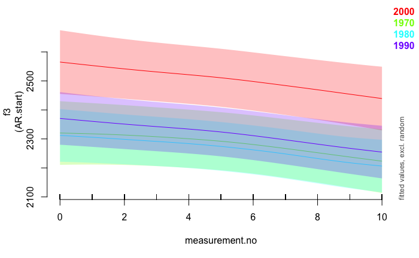

```r
R.m.full.plot <- plot_smooth(R.m.mod.AR, view="measurement.no", plot_all="decade",
            cond=list(stress="full"), rm.ranef=T, n.grid=100)$fv
```

```
Predictor decade is not a factor.
```

```
Summary:
    * stress : factor; set to the value(s): schwa.
    * measurement.no : numeric predictor; with 100 values ranging from 0.000000 to 10.000000.
    * decade : numeric predictor; with 4 values ranging from 1970.000000 to 2000.000000.
    * duration : numeric predictor; set to the value(s): 0.122709575.
    * preceding.front : numeric predictor; set to the value(s): 1.
    * foll.broad.f3 : factor; set to the value(s): labial. (Might be canceled as random effect, check below.)
    * speaker : factor; set to the value(s): 00-O-m06. (Might be canceled as random effect, check below.)
    * word : factor; set to the value(s): were. (Might be canceled as random effect, check below.)
    * NOTE : The following random effects columns are canceled: s(measurement.no,foll.broad.f3),s(measurement.no,speaker),s(measurement.no,word)
```

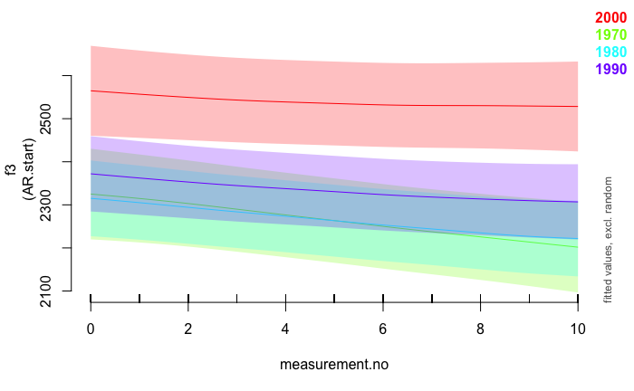

```r
R.m.schwa.plot <- plot_smooth(R.m.mod.AR, view="measurement.no", plot_all="decade",
            cond=list(stress="schwa"), rm.ranef=T, n.grid=100)$fv
```

```r
R.m.plot <- rbind(R.m.full.plot, R.m.schwa.plot)
R.m.plot$decade <- factor(R.m.plot$decade, levels=c("1970","1980","1990","2000"))

ggplot(R.m.plot, aes(x=measurement.no, y=fit, group=decade, col=decade, lty=decade)) +
  geom_line(lwd=1) +
  facet_grid(.~stress) +
  geom_ribbon(aes(ymin=ll, ymax=ul, group=decade), col=NA,col="grey", alpha=0.1) +
  #scale_color_manual(name="sex",breaks=c("F","M"), labels=c("female", "male"),
  #                   values=c("deepskyblue4","firebrick3")) +
  #scale_fill_manual(name="sex",breaks=c("F","M"), labels=c("female", "male"),
  #                   values=c("deepskyblue4","firebrick3"), guide=F) +
  #scale_x_discrete(name="decade of recording", labels=c(1970,1980,1990,2000), expand=expand_scale(add=c(0.05,1))) +
  scale_color_manual(values=c("orange","darkorange3","deepskyblue1","deepskyblue4"),
                     name="decade of\nrecording") +
  scale_linetype_discrete(name="decade of\nrecording") +
  scale_x_continuous(name="measurement point", limits = c(0, 10), breaks=seq(0,10,2)) +
  scale_y_continuous(name="F3 (Hz)", limits=c(2000, 3050)) +
  theme_bw() +
  theme(axis.title = element_text(size=14),
        axis.text = element_text(size=12),
        legend.title = element_text(size=14, face="bold"),
        legend.text=element_text(size=12),
        plot.title=element_text(size=14, face="bold"),
        panel.grid=element_blank(),
        strip.text=element_text(size=12)) +
  ggtitle("F3 changes for /r/ in males (not controlling for baseline F3)")
```

```
Duplicated aesthetics after name standardisation: colour
```

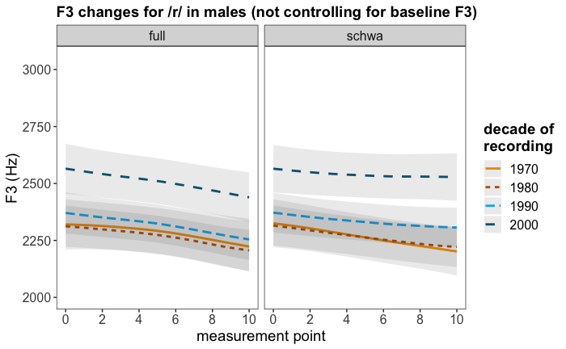

```r
ggsave("graphs/r_male_f3_change_no_control.pdf", width=8, height=4)
```

# Females without baseline control

Fitting:

- model without AR for estimating rho
- full model with AR
- nested model with AR (rho from full model)

```r
if (refit_please) {
  system.time(
    R.f.mod.no.AR <- bam(f3 ~ stress +
                       # level 1 smooth terms
                          s(measurement.no) +
                          s(decade, k=4) +
                          s(duration) +
                          s(preceding.front, k=3) +
                       # level 2: by terms
                          s(measurement.no, by=stress) +
                          s(decade, k=4, by=stress) +
                       # level 2: 2d smooths
                          ti(measurement.no, decade, k=c(10,4)) +
                          ti(measurement.no, duration) +
                          ti(measurement.no, preceding.front, k=c(10,3)) +
                       # level 3: 2d smooth by terms
                          ti(measurement.no, decade, k=c(10,4), by=stress) +
                       # random smooths
                          s(measurement.no, foll.broad.f3, bs="fs", m=1, k=4) +
                          s(measurement.no, speaker, bs="fs", m=1, k=4) +
                          s(measurement.no, word, bs="fs", m=1, k=4),
                      dat=R.f)
  )
  # saveRDS(R.f.mod.no.AR, "models/R.f.mod.no.AR")

  R.f.rho <- start_value_rho(R.f.mod.no.AR)

  system.time(
    R.f.mod.AR <- bam(f3 ~ stress +
                       # level 1 smooth terms
                          s(measurement.no) +
                          s(decade, k=4) +
                          s(duration) +
                          s(preceding.front, k=3) +
                       # level 2: by terms
                          s(measurement.no, by=stress) +
                          s(decade, k=4, by=stress) +
                       # level 2: 2d smooths
                          ti(measurement.no, decade, k=c(10,4)) +
                          ti(measurement.no, duration) +
                          ti(measurement.no, preceding.front, k=c(10,3)) +
                       # level 3: 2d smooth by terms
                          ti(measurement.no, decade, k=c(10,4), by=stress) +
                       # random smooths
                          s(measurement.no, foll.broad.f3, bs="fs", m=1, k=4) +
                          s(measurement.no, speaker, bs="fs", m=1, k=4) +
                          s(measurement.no, word, bs="fs", m=1, k=4),
                      dat=R.f, method="ML",
                      AR.start=R.f$start.event, rho=R.f.rho)
  )
  # saveRDS(R.f.mod.AR, "models/R.f.mod.AR")

  summary(R.f.mod.AR)

  system.time(
    R.f.mod.AR.min.decade <- bam(f3 ~ stress +
                       # level 1 smooth terms
                          s(measurement.no) +
                          #s(decade, k=4) +
                          s(duration) +
                          s(preceding.front, k=3) +
                       # level 2: by terms
                          s(measurement.no, by=stress) +
                          #s(decade, k=4, by=stress) +
                       # level 2: 2d smooths
                          #ti(measurement.no, decade, k=c(10,4)) +
                          ti(measurement.no, duration) +
                          ti(measurement.no, preceding.front, k=c(10,3)) +
                       # level 3: 2d smooth by terms
                          #ti(measurement.no, decade, k=c(10,4), by=stress) +
                       # random smooths
                          s(measurement.no, foll.broad.f3, bs="fs", m=1, k=4) +
                          s(measurement.no, speaker, bs="fs", m=1, k=4) +
                          s(measurement.no, word, bs="fs", m=1, k=4),
                      dat=R.f, method="ML",
                      AR.start=R.f$start.event, rho=R.f.rho)
  )
  # saveRDS(R.f.mod.AR.min.decade, "models/R.f.mod.AR.min.decade")
}
R.f.mod.no.AR <- readRDS("models/R.f.mod.no.AR")
R.f.mod.AR <- readRDS("models/R.f.mod.AR")
R.f.mod.AR.min.decade <- readRDS("models/R.f.mod.AR.min.decade")
compareML(R.f.mod.AR, R.f.mod.AR.min.decade)
```

```
R.f.mod.AR: f3 ~ stress + s(measurement.no) + s(decade, k = 4) + s(duration) +
    s(preceding.front, k = 3) + s(measurement.no, by = stress) +
    s(decade, k = 4, by = stress) + ti(measurement.no, decade,
    k = c(10, 4)) + ti(measurement.no, duration) + ti(measurement.no,
    preceding.front, k = c(10, 3)) + ti(measurement.no, decade,
    k = c(10, 4), by = stress) + s(measurement.no, foll.broad.f3,
    bs = "fs", m = 1, k = 4) + s(measurement.no, speaker, bs = "fs",
    m = 1, k = 4) + s(measurement.no, word, bs = "fs", m = 1,
    k = 4)

R.f.mod.AR.min.decade: f3 ~ stress + s(measurement.no) + s(duration) + s(preceding.front,
    k = 3) + s(measurement.no, by = stress) + ti(measurement.no,
    duration) + ti(measurement.no, preceding.front, k = c(10,
    3)) + s(measurement.no, foll.broad.f3, bs = "fs", m = 1,
    k = 4) + s(measurement.no, speaker, bs = "fs", m = 1, k = 4) +
    s(measurement.no, word, bs = "fs", m = 1, k = 4)

Chi-square test of ML scores
-----
```

| Model | Score | Edf | Difference | Df | p.value | Sig. |
| --- | --- | --- | --- | --- | --- | --- |
| R.f.mod.AR.min.decade | 25888.44 | 22 |  |  |  |  |
| R.f.mod.AR | 25875.82 | 32 | 12.623 | 10.000 | 0.005 | ** |

```
AIC difference: -7.77, model R.f.mod.AR has lower AIC.
```

```
 AIC might not be reliable, as an AR1 model is included (rho1 = 0.850619, rho2 = 0.850619).
```

```
Predictor decade is not a factor.
```

```
Summary:
    * stress : factor; set to the value(s): full.
    * measurement.no : numeric predictor; with 30 values ranging from 0.000000 to 10.000000.
    * decade : numeric predictor; with 4 values ranging from 1970.000000 to 2000.000000.
    * duration : numeric predictor; set to the value(s): 0.103923377.
    * preceding.front : numeric predictor; set to the value(s): 1.
    * foll.broad.f3 : factor; set to the value(s): coronal. (Might be canceled as random effect, check below.)
    * speaker : factor; set to the value(s): 00-O-f01. (Might be canceled as random effect, check below.)
    * word : factor; set to the value(s): were. (Might be canceled as random effect, check below.)
    * NOTE : The following random effects columns are canceled: s(measurement.no,foll.broad.f3),s(measurement.no,speaker),s(measurement.no,word)
```

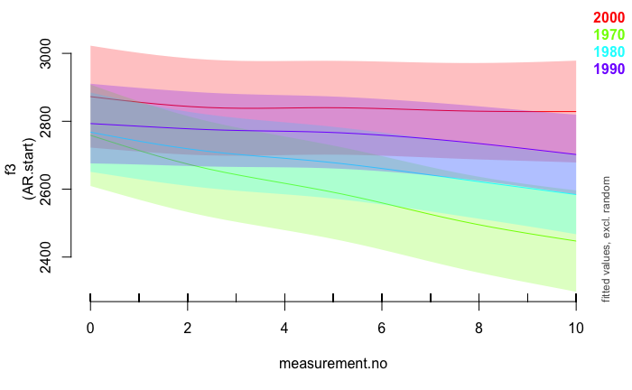

```r
plot_smooth(R.f.mod.AR, view="measurement.no", plot_all="decade",
            cond=list(stress="full"), rm.ranef=T)
```